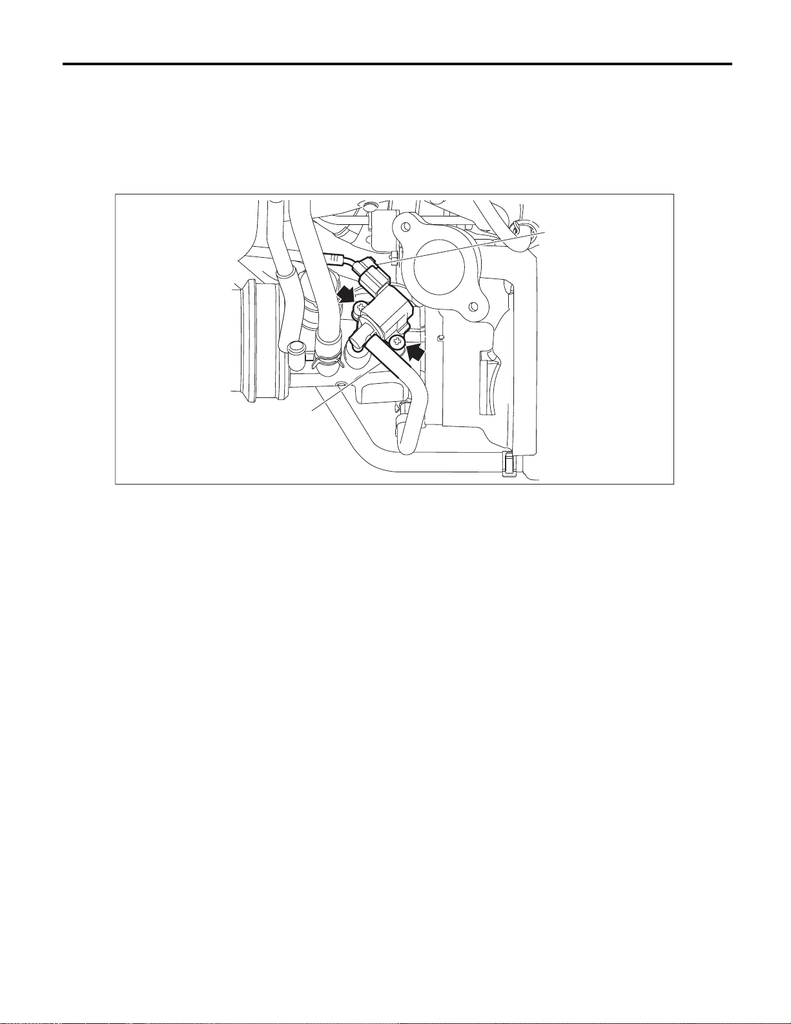

FU(w/o STI)-123

Wastegate Control Solenoid Valve

FUEL INJECTION (FUEL SYSTEMS)

21.Wastegate Control Solenoid Valve

A: REMOVAL

1) Disconnect the ground terminal from battery sensor. <Ref. to NT-5, BATTERY, NOTE, Note.>

2) Remove the intake duct No. 2. <Ref. to IN(w/o STI)-25, INTAKE DUCT NO. 2, REMOVAL, Intake Duct.>

3) Disconnect the connector (A) and vacuum hose (B) from the wastegate control solenoid valve.

4) Remove the wastegate control solenoid valve from the intake duct No. 1.

B: INSTALLATION

Install in the reverse order of removal.

NOTE:

• Use new O-rings.

• When tightening the boost control solenoid valve, check that it is securely seated.

Tightening torque:

2.8 N·m (0.3 kgf-m, 2.1 ft-lb)

FU-08467

(B)

(A)

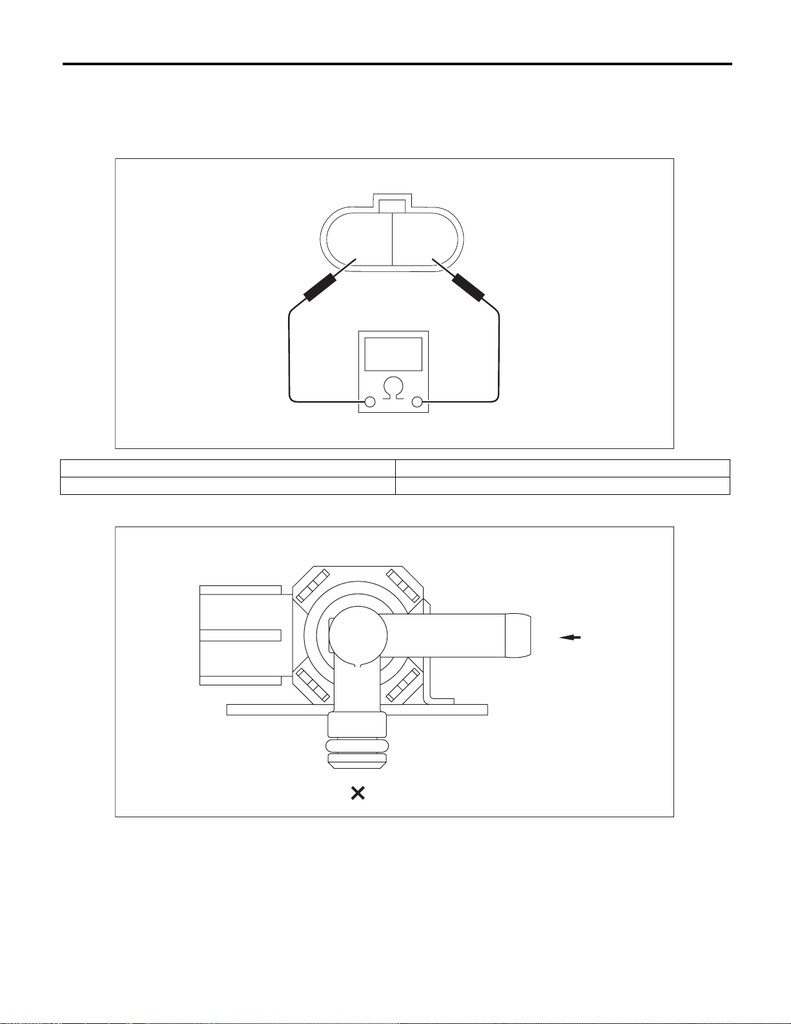

FU(w/o STI)-124

Wastegate Control Solenoid Valve

FUEL INJECTION (FUEL SYSTEMS)

C: INSPECTION

1. WASTEGATE CONTROL SOLENOID VALVE

1) Check that the wastegate control solenoid valve has no deformation, cracks or other damages.

2) Check the resistance between the wastegate control solenoid valve terminals.

3) Check that air does not come out from (B) when air is blown into (A).

Terminal No. Standard

1 and 2 24±3 Ω (when 20°C (68°F))

EC-02799

21

FU-07347

(A)

(B)

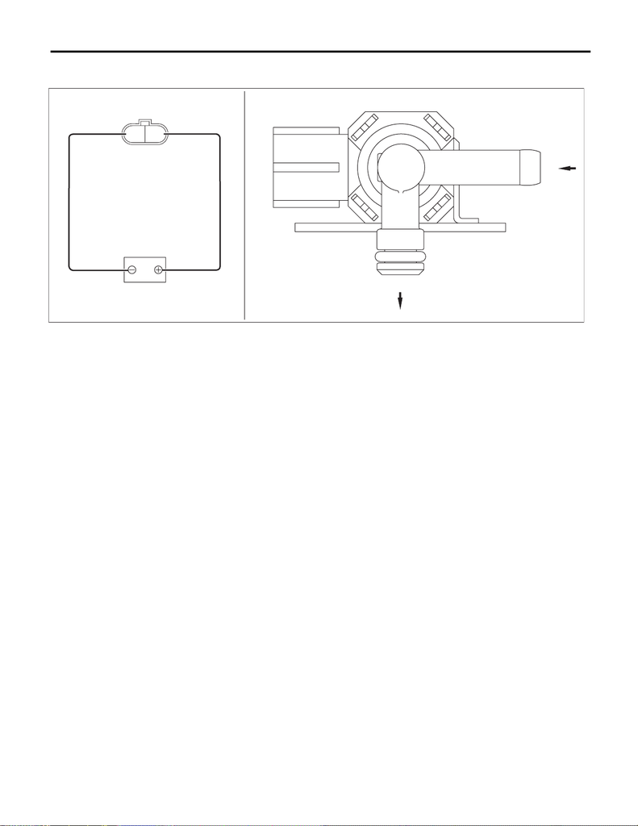

FU(w/o STI)-125

Wastegate Control Solenoid Valve

FUEL INJECTION (FUEL SYSTEMS)

4) Connect the battery positive terminal to the terminal No. 1 and the battery negative terminal to the terminal

No. 2. Check that air is discharged from (B), when supplying air to (A).

2. OTHER INSPECTIONS

Check that the air control hose has no cracks, damage or loose part.

FU-07348

(A)

(B)

21